# A guide to plot aesthetics

`BentoBox` plots are extremely customizable in appearance. In this article we will outline some of the major aesthetic customizations, including general features and specific plot type customizations.

All the data included in this article can be found in the supplementary package `BentoBoxData`.

# `gpar` and common plot customizations

The most common types of customizations are inherited from `grid` `gpar` options. If a function accepts `...`, this usually refers to `gpar` options that are not explicity listed as parameters in the function documentation. General valid parameters include:

| **alpha** | Alpha channel for transparency (number between 0 and 1). |
| --- | --- |
| **fill** | Fill color. |
| **linecolor** | Line color. |
| **lty** | Line type. (0=blank, 1=solid, 2=dashed, 3=dotted, 4=dotdash, 5=longdash, 6=twodash). |
| **lwd** | Line width. |
| **lineend** | Line end style (round, butt, square). |
| **linejoin** | Line join style (round, mitre, bevel). |
| **linemitre** | Line mitre limit (number greater than 1). |
| **fontsize** | The size of text, in points. |
| **fontcolor** | Text color. |
| **fontface** | The font face (plain, bold, italic, bold.italic, oblique). |
| **fontfamily** | The font family. |
| **cex** | Scaling multiplier applied to symbols. |
| **pch** | Plotting character, or symbol (integer codes range from 0 to 25). |

Additional fonts for the `fontfamily` argument can be imported with the packages `extrafont` and `showtext`. This makes it possible to incorporate special fonts like Times New Roman, Arial, etc. into `BentoBox` figures.

# Backgrounds and baselines

By default, `BentoBox` plots have transparent backgrounds when placed on a `bb_page`. In many functions, this background color can be changed with the parameter `bg`.

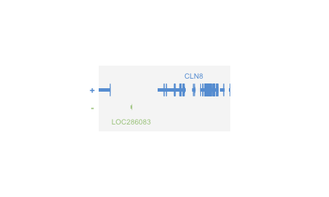

```r
bb_plotGenes(
    chrom = "chr8", chromstart = 1000000, chromend = 2000000,
    assembly = "hg19",
    bg = "#f6f6f6",
    x = 0.5, y = 0.5, width = 2, height = 1, just = c("left", "top"),
    default.units = "inches"
)
```

This makes it easy to clearly see the precise dimensional boundaries of `BentoBox` plots.

Some plots also benefit from baselines to quickly show where y = 0. This can aid in data interpretation and guide plot annotation placement. Baselines can be plotted in selective plots with `baseline = TRUE`.

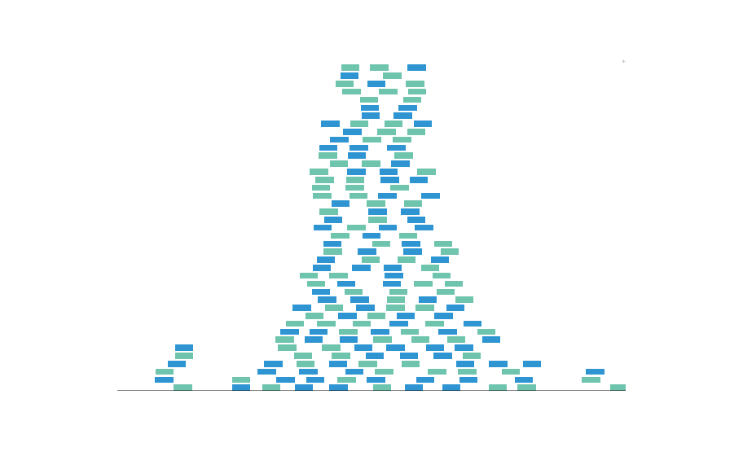

```r
bb_plotRanges(
    data = bb_bedData,
    chrom = "chr21", chromstart = 29073000, chromend = 29074000,
    assembly = "hg19",
    fill = c("#7ecdbb", "#37a7db"),
    baseline = TRUE, baseline.color = "black",
    x = 0.5, y = 0.25, width = 6.5, height = 4.25,
    just = c("left", "top"), default.units = "inches"
)
```

# `colorby`

The `colorby` constructor allows us to color the data elements in `BentoBox` plots by various data features. These features can be a numerical range, like some kind of score value, or categorical values, like positive or negative strand. The `colorby` object is constructed by specifying the name of the data column to color by, an optional color palette function, and an optional range for numerical values. If not specified, `BentoBox` will use the `RColorBrewer` “YlGnBl” palette for mapping numerical data and the “Pairs” palette for qualitative data.

For example, if we revist the BED plot above, `bb_bedData` has an additional `strand` column for each BED element:

```r
data("bb_bedData")
head(bb_bedData)
```

```
#>          chrom    start      end strand
#> 15554862 chr21 28000052 28000088      -
#> 15554863 chr21 28000092 28000128      -
#> 15554864 chr21 28000162 28000198      -
#> 15554865 chr21 28000251 28000287      +
#> 15554866 chr21 28000335 28000371      -
#> 15554867 chr21 28000500 28000536      +
```

Thus, we can use the `colorby` constructor to color BED elements by positive or negative strand. The `strand` column will be converted to a factor with a `-` level and `+` level. These values will be mapped to our input `palette`:

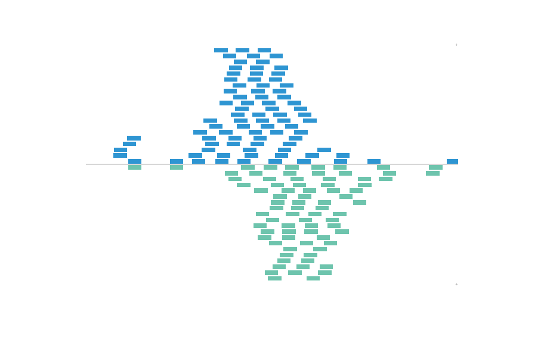

```r
set.seed(nrow(bb_bedData))
bb_plotRanges(
    data = bb_bedData,
    chrom = "chr21", chromstart = 29073000, chromend = 29074000,
    assembly = "hg19",
    fill = colorby("strand", palette =
                       colorRampPalette(c("#7ecdbb", "#37a7db"))),
    x = 0.5, y = 0.25, width = 6.5, height = 4.25,
    just = c("left", "top"), default.units = "inches"
)
```

To further control the order of color mapping, we can set our categorical `colorby` column as a factor with our own order of levels before plotting:

```r
data("bb_bedData")
bb_bedData$strand <- factor(bb_bedData$strand, levels = c("+", "-"))
head(bb_bedData$strand)
```

```
#> [1] - - - + - +
#> Levels: + -
```

Now we’ve set the `+` level as our first level, so our `palette` will map colors in the opposite order from before:

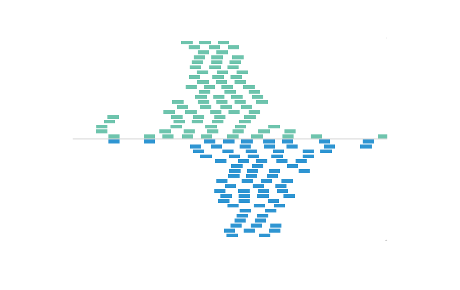

In this example, we will color BEDPE arches by a range of numerical values we will add as a `length` column:

```r
data("bb_bedpeData")
bb_bedpeData$length <- (bb_bedpeData$start2 - bb_bedpeData$start1) / 1000
head(bb_bedpeData$length)
```

```
#> [1]   65 1960 2100  850 1200 1485
```

Now we can set `fill` as a `colorby` object to color the BEDPE `length` column by:

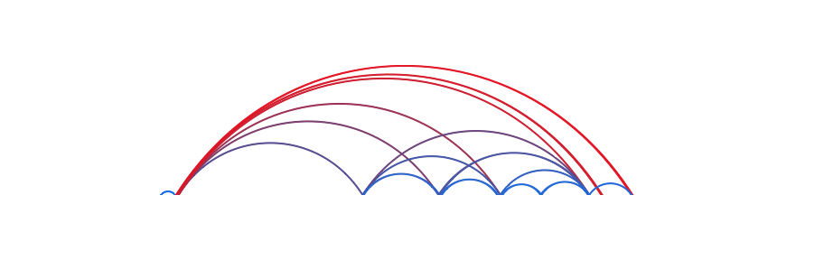

```r
bedpePlot <- bb_plotPairsArches(
    data = bb_bedpeData,
    chrom = "chr21", chromstart = 27900000, chromend = 30700000,
    assembly = "hg19",
    fill = colorby("length",
                   palette = colorRampPalette(c("dodgerblue2", "firebrick2"))),
    linecolor = "fill",
    archHeight = bb_bedpeData$length / max(bb_bedpeData$length),
    alpha = 1,
    x = 0.25, y = 0.25, width = 7, height = 1.5,
    just = c("left", "top"),
    default.units = "inches"
)
```

And now since we have numbers mapped to colors, we can use `bb_annoHeatmapLegend()` with our `bb_arches` object to add a legend for the `colorby` we performed:

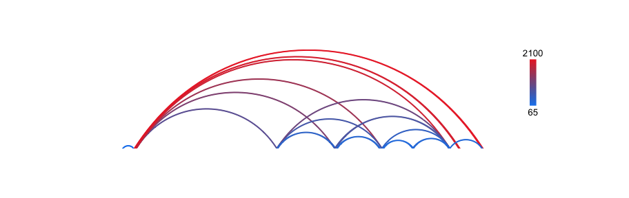

```r
bb_annoHeatmapLegend(
    plot = bedpePlot, fontcolor = "black",
    x = 7.0, y = 0.25,
    width = 0.10, height = 1, fontsize = 10
)
```

# Gene and transcript plot aesthetics

`BentoBox` provides many useful features specific for enhancing gene and transcript visualizations:

## Labels

Since `BentoBox` utilizes `TxDb` objects, `orgDb` objects, and internal citation information, `BentoBox` has access to numerous gene and transcript identifiers and can customize annotation labels in a variety of ways.

By default, `BentoBox` will rank gene labels according to citation number to prevent label overcrowding. However, we can provide our own list of prioritized genes to label in a plot. For example, if we plot the hg19 genes in the region `chr2:1000000-20000000`, our plot will show these labels:

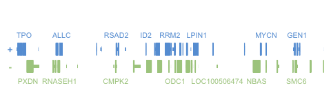

```r
bb_pageCreate(
    width = 5, height = 1.25,
    showGuides = FALSE, xgrid = 0, ygrid = 0
)
genePlot <- bb_plotGenes(
    chrom = "chr2", chromstart = 1000000, chromend = 20000000,
    assembly = "hg19",
    x = 0.25, y = 0.25, width = 4.75, height = 1
)
```

Looking in the `bb_genes` object, we can see that there were numerous genes that were not labeled.

```r
genePlot$genes
```

```
#>  [1] "MIR3125"      "RNASEH1-AS1"  "LOC100506274" "MIR4757"      "LINC00570"
#>  [6] "C2orf50"      "SLC66A3"      "SILC1"        "LRATD1"       "DDX1"
#> [11] "LPIN1"        "ATP6V1C2"     "IAH1"         "TRIB2"        "GRHL1"
#> [16] "HPCAL1"       "ID2"          "MSGN1"        "GEN1"         NA
#> [21] "KCNF1"        "KCNS3"        "LOC400940"    "MYCN"         "TRAPPC12"
#> [26] "CPSF3"        "SNTG2"        "ALLC"         "RPS7"         "RRM2"
#> [31] "SOX11"        "TPO"          "MYT1L-AS1"    "VSNL1"        "COLEC11"
#> [36] "KLF11"        "ASAP2"        "TAF1B"        "RSAD2"        "GREB1"
#> [41] "RNF144A"      "SNORA80B"     "MIR4261"      "MIR4262"      "LINC01304"
#> [46] "LOC100506474" "NT5C1B-RDH14" "MIR4429"      "PDIA6"        "MYCNOS"
#> [51] "YWHAQ"        "CMPK2"        "MBOAT2"       "OSR1"         "E2F6"
#> [56] "CYS1"         "MYT1L"        "NTSR2"        "RNASEH1"      "FLJ33534"
#> [61] "LINC00298"    "LINC00299"    "GRASLND"      "LINC00487"    "ODC1"
#> [66] "NBAS"         "ADI1"         "KIDINS220"    "RDH14"        "ADAM17"
#> [71] "EIPR1"        "LINC01249"    "RAD51AP2"     "PXDN"         "SMC6"
#> [76] "NOL10"        "CYRIA"        "ITGB1BP1"     "NT5C1B"       "ROCK2"
```

If we were particularly interested in MIR3125, we could include this in the `geneOrder` parameter to prioritize its labeling:

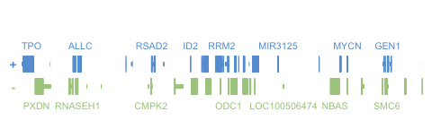

```r
bb_pageCreate(
    width = 5, height = 1.25,
    showGuides = FALSE, xgrid = 0, ygrid = 0
)
genePlot <- bb_plotGenes(
    chrom = "chr2", chromstart = 1000000, chromend = 20000000,
    assembly = "hg19",
    geneOrder = c("MIR3125"),
    x = 0.25, y = 0.25, width = 4.75, height = 1
)
```

If we wanted to change the type of label in our plot, we can change the `display.column` parameter in a `bb_assembly()` object. The default `display.column = "SYMBOL"`, but we could change this value to other available `keytypes` in the `orgDb` we are using. For example, if we wanted to display the associated Ensembl IDs, we would set `display.column = "ENSEMBL"`:

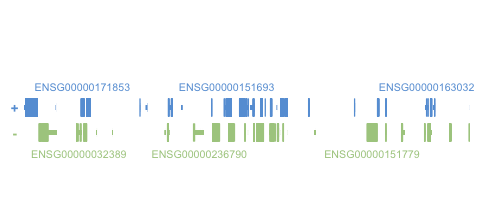

```r
new_hg19 <- bb_assembly(
    Genome = "id_hg19",
    TxDb = "TxDb.Hsapiens.UCSC.hg19.knownGene",
    OrgDb = "org.Hs.eg.db",
    gene.id.column = "ENTREZID",
    display.column = "ENSEMBL"
)
bb_pageCreate(
    width = 5, height = 1.25,
    showGuides = FALSE, xgrid = 0, ygrid = 0
)
genePlot <- bb_plotGenes(
    chrom = "chr2", chromstart = 1000000, chromend = 20000000,
    assembly = new_hg19,
    x = 0.25, y = 0.25, width = 4.75, height = 1
)
```

Label IDs used in transcript plots can be customized through `bb_assembly()` objects, and transcript label formatting can be changed through the `labels` parameter. For example, if we wish to display both transcript names and their associated gene names, we can set `labels = "both"`:

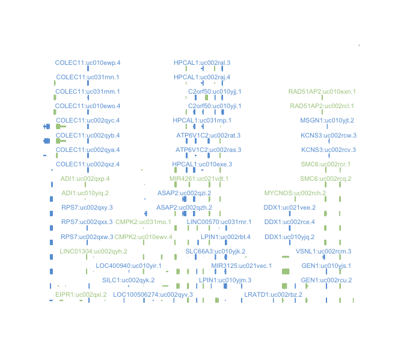

```r
bb_pageCreate(
    width = 6, height = 5,
    showGuides = FALSE, xgrid = 0, ygrid = 0
)
transcriptPlot <- bb_plotTranscripts(
    chrom = "chr2", chromstart = 1000000, chromend = 20000000,
    assembly = "hg19",
    labels = "both",
    x = 0.25, y = 0.25, width = 5.5, height = 4.5
)
```

## Highlighting genes by color

In addition to changing `fill` and `fontcolor` to change the colors of all genes in a plot, specific gene structures and their labels can be highlighted in a different color with `geneHighlights`. If we revisit the `bb_genes` plot above, we can highlight RRM2 by creating a `data.frame` with “RRM2” in the first column and its highlight color in the second column:

```r
geneHighlights <- data.frame("geneName" = "RRM2", "color" = "steel blue")
```

We can then pass this into our `bb_plotGenes()` call:

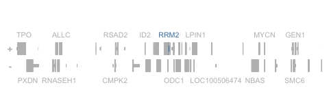

```r
bb_pageCreate(
    width = 5, height = 1.25,
    showGuides = FALSE, xgrid = 0, ygrid = 0
)
genePlot <- bb_plotGenes(
    chrom = "chr2", chromstart = 1000000, chromend = 20000000,
    assembly = "hg19",
    geneHighlights = geneHighlights, geneBackground = "grey",
    x = 0.25, y = 0.25, width = 4.75, height = 1
)
```

Since `geneHighlights` is a `data.frame`, we can highlight multiple genes in different colors at once. For example, let’s now highlight RRM2 in “steel blue” and PXDN in “red”:

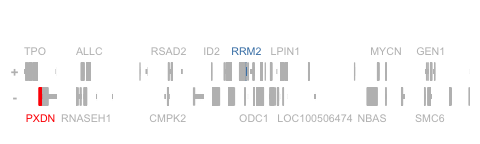

```r
geneHighlights <- data.frame(
    "geneName" = c("RRM2", "PXDN"),
    "color" = c("steel blue", "red")
)

bb_pageCreate(
    width = 5, height = 1.25,
    showGuides = FALSE, xgrid = 0, ygrid = 0
)
genePlot <- bb_plotGenes(
    chrom = "chr2", chromstart = 1000000, chromend = 20000000,
    assembly = "hg19",
    geneHighlights = geneHighlights, geneBackground = "grey",
    x = 0.25, y = 0.25, width = 4.75, height = 1
)
```

## Customizing transcripts by strand

To distinguish which strand a transcript belongs to, `bb_plotTranscripts()` colors transcripts by strand with the parameter `colorbyStrand`. The first value in `fill` colors positive strand transcripts and the second `fill` value colors negative strand transcripts. To further organize transcripts by strand, we can use `strandSplit` to separate transcript elements into groups of positive and negative strands:

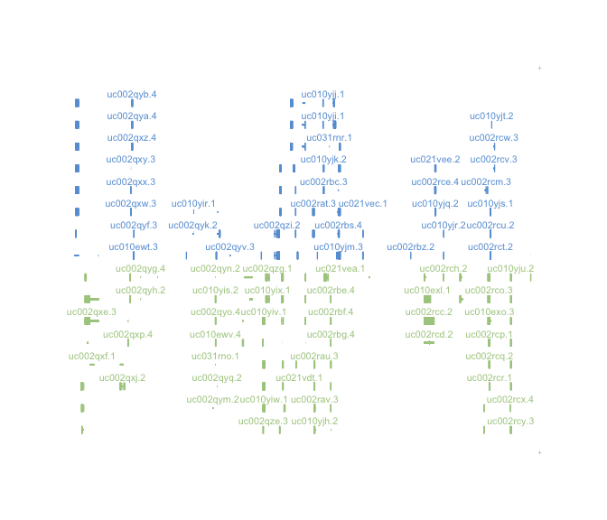

```r
bb_pageCreate(
    width = 6, height = 5,
    showGuides = FALSE, xgrid = 0, ygrid = 0
)
transcriptPlot <- bb_plotTranscripts(
    chrom = "chr2", chromstart = 1000000, chromend = 20000000,
    assembly = "hg19",
    strandSplit = TRUE,
    x = 0.25, y = 0.25, width = 5.5, height = 4.5
)
```

Now all our positive strand transcripts are grouped together above the group of negative strand transcripts.

# Hi-C plot customizations

`BentoBox` includes many types of customizations for Hi-C plots. `BentoBox` provides 3 different Hi-C plotting functions based on the desired plot shape:

- `bb_plotHicSquare()`: Plots a square, symmetrical Hi-C plot with genomic coordinates along both the x- and y-axes.
- `bb_plotHicTriangle()`: Plots a triangular Hi-C plot where the genome region falls along the base of the triangle.
- `bb_plotHicRectangle()`: Plots a triangular Hi-C plot with additional data filling the surrounding regions to form a rectangle.

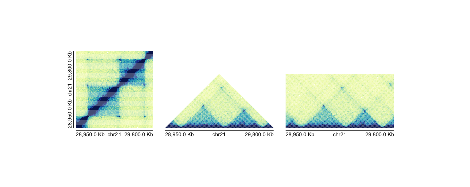

All Hi-C plot types can use different color palettes, and colors can be linearly or log-scaled with the `colorTrans` parameter.

`bb_hicSquare` plots can be further customized to include two datasets in one plot. Instead of plotting both symmetrical halves of the plot, we can set one dataset as `half = "top"` and the other dataset as `half = "bottom"`:

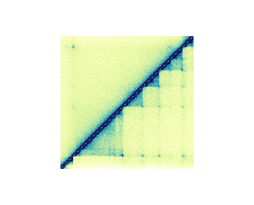

```r
data("bb_gmHicData")
data("bb_imrHicData")

bb_pageCreate(
    width = 3.25, height = 3.25, default.units = "inches",
    showGuides = FALSE, xgrid = 0, ygrid = 0
)
params <- bb_params(
    chrom = "chr21", chromstart = 28000000, chromend = 30300000,
    assembly = "hg19", resolution = 10000,
    x = 0.25, width = 2.75, just = c("left", "top"), default.units = "inches"
)


hicPlot_top <- bb_plotHicSquare(
    data = bb_gmHicData, params = params,
    zrange = c(0, 200),
    half = "top",
    y = 0.25, height = 2.75
)
hicPlot_bottom <- bb_plotHicSquare(
    data = bb_imrHicData, params = params,
    zrange = c(0, 70),
    half = "bottom",
    y = 0.25, height = 2.75
)
```